# Data Mining / Prospecção de Dados

## 6. Clustering Samples using Density-based Clustering

Use DBSCAN (https://scikit-learn.org/stable/modules/generated/sklearn.cluster.DBSCAN.html) or OPTICS (https://scikit-learn.org/stable/modules/generated/sklearn.cluster.OPTICS.html) to cluster the samples.

Compare the results with those of K-means and HCA.

```python
clustering = DBSCAN(eps=75, min_samples=3).fit(X_variance[X_variance_cols])
```

```python
X_PCA.loc[X_PCA['class'] == 'MB-CL', ['class']] = 1
X_PCA.loc[X_PCA['class'] == 'Other', ['class']] = 0
```

```python
X_PCA.head()
```

|  | PC1 | PC2 | PC3 | PC4 | PC5 | PC6 | PC7 | PC8 | PC9 | PC10 | ... | hca_single_6 | hca_single_7 | hca_single_8 | hca_ward_2 | hca_ward_3 | hca_ward_4 | hca_ward_5 | hca_ward_6 | hca_ward_7 | hca_ward_8 |
| --- | --- | --- | --- | --- | --- | --- | --- | --- | --- | --- | --- | --- | --- | --- | --- | --- | --- | --- | --- | --- | --- |
| 0 | 0.029922 | -0.107290 | 0.294937 | -0.051187 | 0.262091 | 0.061769 | -0.282882 | -0.445573 | -0.093255 | 0.121860 | ... | 0 | 0 | 0 | 0 | 2 | 2 | 0 | 2 | 2 | 0 |
| 1 | 0.332719 | 0.022127 | 0.028202 | -0.111946 | -0.051869 | 0.120865 | -0.146962 | 0.085687 | 0.126221 | -0.099427 | ... | 5 | 5 | 5 | 0 | 0 | 0 | 2 | 0 | 6 | 2 |
| 2 | 0.219280 | 0.384784 | -0.009728 | 0.048099 | 0.104373 | 0.127275 | -0.264678 | 0.203901 | 0.018319 | 0.002863 | ... | 2 | 6 | 6 | 0 | 0 | 0 | 2 | 0 | 6 | 2 |
| 3 | 0.199220 | -0.200396 | 0.292435 | -0.270997 | 0.396613 | -0.261462 | -0.269668 | -0.088894 | -0.309930 | -0.256963 | ... | 0 | 0 | 0 | 0 | 2 | 2 | 0 | 2 | 2 | 0 |
| 4 | -0.005481 | 0.188714 | 0.224270 | -0.316550 | -0.062750 | -0.074120 | 0.083618 | 0.004166 | 0.163433 | -0.095477 | ... | 0 | 0 | 0 | 0 | 0 | 0 | 2 | 0 | 6 | 2 |

5 rows × 58 columns

## DBSCAN Clustering

Vantagens:  
É capaz de identificar noise points enquanto realiza o clustering.  
O algoritmo é capaz de encontrar clusters com tamanhos e formatos arbritários.

Desvantagens:  
Este algoritmo beneficia quando o dataset utilizado tem muitos exemplos no caso do dataset utilizado para este projeto apenas temos 76 elementos, que para este algoritmo revela ser muito pouco para conseguirmos ter uma performance relevante e uma boa separação dos clusters.  
Também temos que para este algoritmo não queremos high dimensional data, pois com este tipo de dados tende a não funcionar bem, e logo representa numa descida de performance

```python
# Function to obtain an array containing the info about the clustering to be then showed on the DataFrame
# Receives as input the DataFrame, the labels calculates by the clustering method, the true labelsof which cluster the instance belongs to,
# the model with we used to calculate the clusters, and the min samples used by the model
# Returns as output the array that contains the various metrics used to analize the clustering (Homogeneity, Completeness, V Measure, Adjusted Rand, Adjusted Mutual info and Silhouette), and the parameters used  by the model

def get_cluster_info(data, labels, labels_true, model, min_samples):
    info_ar = []
    info_ar.append(model)
    info_ar.append(min_samples)
    info_ar.append(len(set(labels)) - (1 if -1 in labels else 0))
    info_ar.append(list(labels).count(-1))
    info_ar.append(metrics.homogeneity_score(labels_true, labels))
    info_ar.append(metrics.completeness_score(labels_true, labels))
    info_ar.append(metrics.v_measure_score(labels_true, labels))
    info_ar.append(metrics.adjusted_rand_score(labels_true, labels))
    info_ar.append(metrics.adjusted_mutual_info_score(labels_true, labels))
    info_ar.append(metrics.silhouette_score(data, labels))

    return info_ar
```

```python
# Function to obtain the labels calculated by the DBSCAN algorithm
# Receives as input the DataFrame, the Cols used to fit on DBSCAN,
# the value of eps (The maximum distance between two samples for one to be considered as in the neighborhood of the other),
# and the number of min samples (The number of samples (or total weight) in a neighborhood for a point to be considered as a core point)
# Returns as output the labels of the cluster of each instance calculated by the DBSCAN, and the true labels of the instances

def dbscan_labels(df, cols, eps, min_samples):
    db = DBSCAN(eps = eps, min_samples = min_samples).fit(df[cols])
    core_samples_mask = np.zeros_like(db.labels_, dtype=bool)
    core_samples_mask[db.core_sample_indices_] = True

    labels = db.labels_

    labels_true =  df['class']

    return labels, labels_true
```

```python
cols = ['Model', 'Min Samples', 'Num Clusters', 'Noise Points', 'Homogeneity', 'Completeness', 'V Measure', 'Adjusted Rand Index', 'Adjusted Mutual Information', 'Silhouette Coefficient']
```

Para esta escolha de parâmetros, realizámos este algoritmo com várias configurações e chegámos à conclusão através da definição dos clusters que este valor de **epsilon**, seria o mais apropriado mas mesmo assim os clusters formados não são os melhores.

De tal forma, realizamos um ciclo para obtermos os valores dos clusters feitos pelo DBSCAN, para diferentes valores de **min_samples**, desta forma podemos analisar mais à frente qual o valor que melhor métricas obtêm decidir assim, qual vamos usar para a comparação de resultados.

```python
# Compute DBSCAN
info_cluster_ar = []
best_sample = 0
for samples in range (1,10):
    labels, labels_true = dbscan_labels(X_PCA, X_PCA_cols, 1.1, samples)

    info_cluster_ar.append(get_cluster_info(X_PCA[X_PCA_cols], labels, labels_true, 'DBSCAN_PCA', samples))

df = pd.DataFrame(info_cluster_ar, columns = cols)
column = df["V Measure"]
best_sample_pca = df.iloc[column.idxmax()]['Min Samples']
```

## X_Variance DBSCAN

```python
X_variance.loc[X_variance['class'] == 'MB-CL', ['class']] = 1
X_variance.loc[X_variance['class'] == 'Other', ['class']] = 0
```

```python
# Compute DBSCAN
for samples in range (1,10):
    db = DBSCAN(eps=0.23, min_samples = samples, algorithm = 'kd_tree').fit(X_variance[X_variance_cols])
    core_samples_mask = np.zeros_like(db.labels_, dtype=bool)
    core_samples_mask[db.core_sample_indices_] = True

    labels = db.labels_

    labels_true =  X_variance['class']

    info_cluster_ar.append(get_cluster_info(X_variance[X_variance_cols], labels, labels_true, 'DBSCAN_Variance', samples))

df = pd.DataFrame(info_cluster_ar, columns = cols)
column = df["V Measure"]
best_sample_variance = df.iloc[column.idxmax()]['Min Samples']
```

```python
info_cluster_df = pd.DataFrame(info_cluster_ar, columns = cols)
info_cluster_df
```

|  | Model | Min Samples | Num Clusters | Noise Points | Homogeneity | Completeness | V Measure | Adjusted Rand Index | Adjusted Mutual Information | Silhouette Coefficient |
| --- | --- | --- | --- | --- | --- | --- | --- | --- | --- | --- |
| 0 | DBSCAN_PCA | 1 | 15 | 0 | 0.234685 | 0.099714 | 0.139961 | -0.014720 | 0.034028 | -0.013555 |
| 1 | DBSCAN_PCA | 2 | 5 | 10 | 0.090702 | 0.048367 | 0.063091 | -0.021498 | 0.020764 | 0.028634 |
| 2 | DBSCAN_PCA | 3 | 3 | 14 | 0.090702 | 0.055182 | 0.068617 | -0.024778 | 0.043720 | 0.058018 |
| 3 | DBSCAN_PCA | 4 | 3 | 21 | 0.083166 | 0.046716 | 0.059826 | -0.033404 | 0.036086 | 0.063058 |
| 4 | DBSCAN_PCA | 5 | 3 | 27 | 0.087660 | 0.047701 | 0.061782 | -0.027192 | 0.038618 | 0.061717 |
| 5 | DBSCAN_PCA | 6 | 2 | 43 | 0.067219 | 0.046849 | 0.055215 | -0.037737 | 0.037481 | 0.056903 |
| 6 | DBSCAN_PCA | 7 | 4 | 50 | 0.080093 | 0.045878 | 0.058338 | -0.057758 | 0.024349 | 0.039796 |
| 7 | DBSCAN_PCA | 8 | 1 | 67 | 0.005810 | 0.010116 | 0.007381 | -0.031025 | -0.007148 | 0.027142 |
| 8 | DBSCAN_PCA | 9 | 1 | 67 | 0.005810 | 0.010116 | 0.007381 | -0.031025 | -0.007148 | 0.027142 |
| 9 | DBSCAN_Variance | 1 | 16 | 0 | 0.354182 | 0.137816 | 0.198424 | 0.141667 | 0.099412 | 0.016495 |
| 10 | DBSCAN_Variance | 2 | 5 | 11 | 0.204407 | 0.101089 | 0.135277 | 0.137578 | 0.098839 | 0.129800 |
| 11 | DBSCAN_Variance | 3 | 4 | 13 | 0.203056 | 0.106529 | 0.139744 | 0.136208 | 0.110837 | 0.145202 |
| 12 | DBSCAN_Variance | 4 | 4 | 13 | 0.203056 | 0.106529 | 0.139744 | 0.136208 | 0.110837 | 0.145202 |
| 13 | DBSCAN_Variance | 5 | 3 | 18 | 0.203019 | 0.120472 | 0.151213 | 0.134202 | 0.128700 | 0.152722 |
| 14 | DBSCAN_Variance | 6 | 3 | 26 | 0.200191 | 0.111480 | 0.143210 | 0.138316 | 0.121553 | 0.159258 |
| 15 | DBSCAN_Variance | 7 | 2 | 34 | 0.072623 | 0.048084 | 0.057859 | 0.059801 | 0.040902 | 0.134267 |
| 16 | DBSCAN_Variance | 8 | 2 | 34 | 0.072623 | 0.048084 | 0.057859 | 0.059801 | 0.040902 | 0.134267 |
| 17 | DBSCAN_Variance | 9 | 1 | 42 | 0.070114 | 0.064591 | 0.067239 | 0.043721 | 0.057623 | 0.155047 |

## X_PCA OPTICS

Neste vamos utilizar o algoritmo do OPTICS, e comparar com o DBSCAN, e decidir com qual vamos finalmente, utilizar para comparar com os modelos das alíneas anteriores tal como é pedido.  
O processo será semelhante ao realizado antes, e simplesmente vamos nos reger mais pelos valores obtidos no **V Measure** e no número de clusters formados e noise points existentes.

A escolha de parâmetros definida, foi devido a vários testes com o modelo e os valores escolhidos foram os que de pois de analisar funcionavam melhor para cada um dos dados fornecidos.

```python
info_cluster_optics = []
for sample in range(1, 10):
    clustering = OPTICS(min_samples=sample).fit(X_PCA[X_PCA_cols])
    labels = clustering.labels_

    # Number of clusters in labels, ignoring noise if present.
    n_clusters_ = len(set(labels)) - (1 if -1 in labels else 0)
    n_noise_ = list(labels).count(-1)
    labels_true = X_variance['class']

    info_ar = []
    info_ar.append('OPTICS_PCA')
    info_ar.append(sample)
    info_ar.append(n_clusters_)
    info_ar.append(n_noise_)
    info_ar.append(metrics.homogeneity_score(labels_true, labels))
    info_ar.append(metrics.completeness_score(labels_true, labels))
    info_ar.append(metrics.v_measure_score(labels_true, labels))
    info_ar.append(metrics.adjusted_rand_score(labels_true, labels))
    info_ar.append(metrics.adjusted_mutual_info_score(labels_true, labels))

    info_cluster_optics.append(info_ar)
```

```python
labels = clustering.fit_predict(X_PCA[X_PCA_cols], X_PCA['class'])
```

```python
info_cluster_optics_df = pd.DataFrame(info_cluster_optics, columns = cols[:-1])
info_cluster_optics_df
```

|  | Model | Min Samples | Num Clusters | Noise Points | Homogeneity | Completeness | V Measure | Adjusted Rand Index | Adjusted Mutual Information |
| --- | --- | --- | --- | --- | --- | --- | --- | --- | --- |
| 0 | OPTICS_PCA | 1 | 1 | 0 | 0.000000 | 1.000000 | 0.000000 | 0.000000 | 0.000000 |
| 1 | OPTICS_PCA | 2 | 17 | 33 | 0.244261 | 0.069182 | 0.107824 | -0.034611 | 0.007313 |
| 2 | OPTICS_PCA | 3 | 5 | 55 | 0.125067 | 0.077759 | 0.095896 | -0.035644 | 0.049347 |
| 3 | OPTICS_PCA | 4 | 3 | 58 | 0.104980 | 0.083064 | 0.092745 | -0.035856 | 0.062713 |
| 4 | OPTICS_PCA | 5 | 3 | 55 | 0.081491 | 0.057926 | 0.067717 | -0.070861 | 0.039555 |
| 5 | OPTICS_PCA | 6 | 1 | 69 | 0.061562 | 0.126862 | 0.082896 | -0.061967 | 0.068166 |
| 6 | OPTICS_PCA | 7 | 1 | 69 | 0.061562 | 0.126862 | 0.082896 | -0.061967 | 0.068166 |
| 7 | OPTICS_PCA | 8 | 1 | 0 | 0.000000 | 1.000000 | 0.000000 | 0.000000 | 0.000000 |
| 8 | OPTICS_PCA | 9 | 1 | 0 | 0.000000 | 1.000000 | 0.000000 | 0.000000 | 0.000000 |

## X_variance OPTICS

```python
for sample in range(1, 10):
    clustering = OPTICS(min_samples=sample).fit(X_variance[X_variance_cols])
    labels = clustering.labels_

    # Number of clusters in labels, ignoring noise if present.
    n_clusters_ = len(set(labels)) - (1 if -1 in labels else 0)
    n_noise_ = list(labels).count(-1)
    labels_true = X_variance['class']

    info_ar = []
    info_ar.append('OPTICS_Variance')
    info_ar.append(sample)
    info_ar.append(n_clusters_)
    info_ar.append(n_noise_)
    info_ar.append(metrics.homogeneity_score(labels_true, labels))
    info_ar.append(metrics.completeness_score(labels_true, labels))
    info_ar.append(metrics.v_measure_score(labels_true, labels))
    info_ar.append(metrics.adjusted_rand_score(labels_true, labels))
    info_ar.append(metrics.adjusted_mutual_info_score(labels_true, labels))

    info_cluster_optics.append(info_ar)
```

## DBSCAN or OPTICS?

De seguida vamos apresentar alguns plots acerca dos valores obtidos no V Measure e o número de noise points definidos nos diferentes algoritmos e decidir qual deles iremos utilizar.

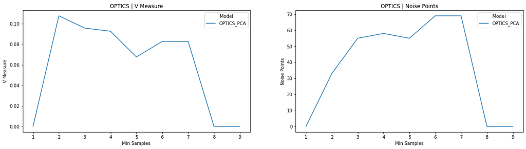

```python
fig, axs = plt.subplots(ncols=2,figsize=(20,5))
axs[0].set_title('OPTICS | V Measure')
axs[1].set_title('OPTICS | Noise Points')
sns.lineplot(data=info_cluster_optics_df, x="Min Samples", y="V Measure", hue = 'Model', ax=axs[0])
sns.lineplot(data=info_cluster_optics_df, x="Min Samples", y="Noise Points", hue = 'Model', ax=axs[1])
```

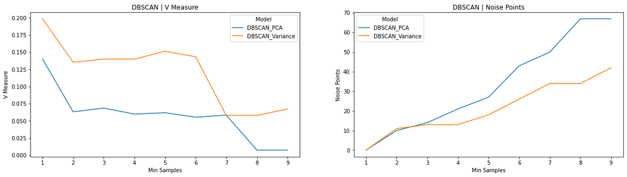

```python
fig, axs = plt.subplots(ncols=2,figsize=(20,5))
axs[0].set_title('DBSCAN | V Measure')
axs[1].set_title('DBSCAN | Noise Points')
sns.lineplot(data=info_cluster_df, x="Min Samples", y="V Measure", hue = 'Model', ax=axs[0])
sns.lineplot(data=info_cluster_df, x="Min Samples", y="Noise Points", hue = 'Model', ax=axs[1])
```

```python
labels, labels_true = dbscan_labels(X_PCA, X_PCA_cols, 1.1, int(best_sample_pca))
labels_2, labels_true_2 = dbscan_labels(X_PCA, X_PCA_cols, 1.1, 2)
labels_3, labels_true_3 = dbscan_labels(X_PCA, X_PCA_cols, 1.1, 3)
```

```python
X_PCA['DBSCAN'] = labels
X_PCA['DBSCAN_2'] = labels_2
X_PCA['DBSCAN_3'] = labels_3
```

```python
labels, labels_true = dbscan_labels(X_variance, X_variance_cols, 0.23, int(best_sample_variance))
labels_2, labels_true_2 = dbscan_labels(X_variance, X_variance_cols, 0.23, 2)
labels_3, labels_true_3 = dbscan_labels(X_variance, X_variance_cols, 0.23, 3)
```

```python
X_variance['DBSCAN'] = labels
X_variance['DBSCAN_2'] = labels_2
X_variance['DBSCAN_3'] = labels_3
```

Adicionamos assim os que achámos serem os valores com resultados mais relevantes na formação de clusters e número de noise points existentes, para ambos os casos foram os 3 primeiro valores de min samples, estes tinham um balanço entre clusters formados e noise points existentes.

Podemos então concluir, que através da utilização do DBSCAN para classificarmos os clusters este apresenta valores melhores de V Measure para o caso de classificarmos o X_Variance, que não era o que esperávamos inicialmente, dado que este algoritmo não costuma funcionar tão bem quando os datasets têm um número de features elevado. Logo, a razão de termos estado à espera que os valores obtidos, quando usamos o X_variance para classificar os clusters, fossem inferiores devido a este ter mais features (+300 features), enquanto que o X_PCA temos 10 Principal Components.

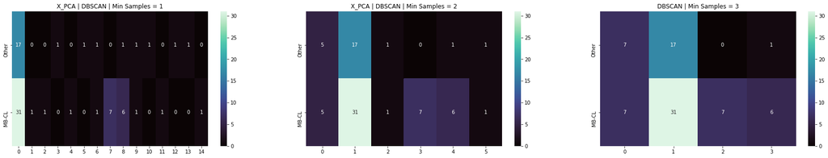

```python
fig, axs = plt.subplots(ncols=3,figsize=(30,5))
axs[0].set_title('X_PCA | DBSCAN | Min Samples = 1')
axs[1].set_title('X_PCA | DBSCAN | Min Samples = 2')
axs[2].set_title('DBSCAN | Min Samples = 3')
sns.heatmap(contingency_matrix(X_PCA['class'], X_PCA['DBSCAN']), annot=True, fmt="d",  cmap="mako", yticklabels = ['Other','MB-CL'],ax=axs[0])
sns.heatmap(contingency_matrix(X_PCA['class'], X_PCA['DBSCAN_2']), annot=True, fmt="d",  cmap="mako", yticklabels = ['Other','MB-CL'],ax=axs[1])
sns.heatmap(contingency_matrix(X_PCA['class'], X_PCA['DBSCAN_3']), annot=True, fmt="d",  cmap="mako", yticklabels = ['Other','MB-CL'],ax=axs[2])
plt.show()
```

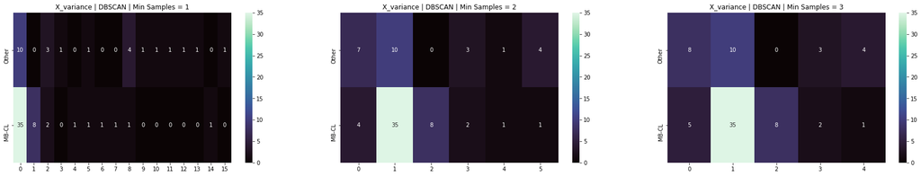

```python
fig, axs = plt.subplots(ncols=3,figsize=(30,5))
axs[0].set_title('X_variance | DBSCAN | Min Samples = 1')
axs[1].set_title('X_variance | DBSCAN | Min Samples = 2')
axs[2].set_title('X_variance | DBSCAN | Min Samples = 3')
sns.heatmap(contingency_matrix(X_variance['class'], X_variance['DBSCAN']), annot=True, fmt="d",  cmap="mako", yticklabels = ['Other','MB-CL'],ax=axs[0])
sns.heatmap(contingency_matrix(X_variance['class'], X_variance['DBSCAN_2']), annot=True, fmt="d",  cmap="mako", yticklabels = ['Other','MB-CL'],ax=axs[1])
sns.heatmap(contingency_matrix(X_variance['class'], X_variance['DBSCAN_3']), annot=True, fmt="d",  cmap="mako", yticklabels = ['Other','MB-CL'],ax=axs[2])
plt.show()
```

Através da análise dos valores obtidos conseguimos assim escolher qual o melhor valor de Min_samples, que vamos utilizar para a comparação de resultados com os algoritmos anteriormente utilizámos.

Para tal, temos que o valor das min_samples que valor superior de **V Measure** é o de min_samples = 1, para o que utilizámos o X_variance, para formar os clusters. No entanto temos que com este valor de min samples temos demasiados clusters formados, tal como no caso do PCA com o mesmo valor de min samples. Sendo assim decidimos utilizar para comparação o valor de min samples igual a 3 para o X_variance, dado que este apresenta ter um bom balanço entre clusters formados e noise points.

Tal como podemos ver nas representações anteriores comparativamente com o X_PCA, o DBSCAN apresenta formar clusters melhores no X_variance, onde consegue separar com mais eficácia a classe do MB-CL, mesmo tendo ainda algumas instâncias da classe Other.

No entanto os clusters formados são relativamente parecidos aos do PCA em relação ao número de clusters formados e noise points presentes, mas o X_variance apresenta melhores resultados para os diversos valores de min samples em relação ao do PCA e tal como foi mencionado antes uma melhor separação das classes.

Dado que o X_variance apresenta valores superiores da métrica **V Measure**,iremos utilizar o X_variance com min samples = 3 para as comparações.

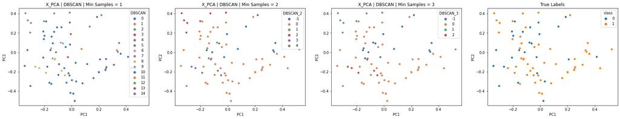

```python
fig, axs = plt.subplots(ncols=4,figsize=(30,5))
axs[0].set_title('X_PCA | DBSCAN | Min Samples = 1')
axs[1].set_title('X_PCA | DBSCAN | Min Samples = 2')
axs[2].set_title('X_PCA | DBSCAN | Min Samples = 3')
axs[3].set_title('True Labels')
sns.scatterplot(data=X_PCA, x='PC1', y='PC2', hue='DBSCAN', palette='deep', ax=axs[0])
sns.scatterplot(data=X_PCA, x='PC1', y='PC2', hue='DBSCAN_2', palette = 'deep', ax=axs[1])
sns.scatterplot(data=X_PCA, x='PC1', y='PC2', hue='DBSCAN_3', palette = 'deep', ax=axs[2])
sns.scatterplot(data=X_PCA, x='PC1', y='PC2', hue='class', ax=axs[3])
plt.show()
```

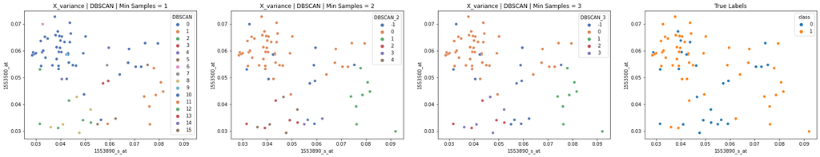

```python
fig, axs = plt.subplots(ncols=4,figsize=(30,5))
axs[0].set_title('X_variance | DBSCAN | Min Samples = 1')
axs[1].set_title('X_variance | DBSCAN | Min Samples = 2')
axs[2].set_title('X_variance | DBSCAN | Min Samples = 3')
axs[3].set_title('True Labels')
sns.scatterplot(data=X_variance, x='1553890_s_at', y='1553500_at', hue='DBSCAN', palette='deep', ax=axs[0])
sns.scatterplot(data=X_variance, x='1553890_s_at', y='1553500_at', hue='DBSCAN_2', palette = 'deep', ax=axs[1])
sns.scatterplot(data=X_variance, x='1553890_s_at', y='1553500_at', hue='DBSCAN_3', palette = 'deep', ax=axs[2])
sns.scatterplot(data=X_variance, x='1553890_s_at', y='1553500_at', hue='class', ax=axs[3])
plt.show()
```

No entanto, os clusters formados não apresentam resultados muito favoráveis devido a uma análise prévia, da distribuição dos pontos nos diferentes PC's, onde os pontos estavam bastante aglomerados e não parecia haver uma divisão dos clusters que fosse realmente bem sucedida. Isto, apresentou-se nos resultados obtidos em que as métricas que usamos para analisar apresentam todas valores muito baixos, e para menores valores de clusters formados (5 clusters ou menos), temos que a quantidade de **noise points** é muito elevada, para os valores que foram utilizados nos parâmetros que foram os que tivemos melhores resultados.

E ao analisarmos os clusters formados nas representações anteriores, podemos ver o que foi mencionado antes, das classes estarem aglomeradas, no entanto no caso do X_variance conseguimos reparar que temos menos aglomeração em comparação com o X_PCA.

Mesmo assim, ao compararmos com o K means e o HCA, continuamos a perceber que o HCA tem melhores clusters formados, dado que este apresentava um cluster puro para a classe Other, enquanto que o DBSCAN apenas consegue criar um cluster puro para a classe MB-CL, e também apresentamos noise points.

Desta forma, o HCA apresentou resultados ainda relativamente melhores aos obtidos com o DBSCAN. No entanto conseguimos ver o potencial que o DBSCAN tem para este tipo de problemas, dado que é capaz de encontrar noise points e independentemente do seu tamanho e formato formar clusters.

## 7. Choose a Different Clustering Algorithm to Group the Samples

Choose **a clustering algorithm** besides `K`-means, HCA and DBSCAN/OPTICS to cluster the samples.

**Groups of 3 People** must choose two different algorithms.

```python
# Definir dfs e cols
cols = [X_variance_cols, X_PCA_cols]
dfs = [X_variance, X_PCA]
```

## Affinity Propagation Clustering

É um algoritmo de *clustering* que deixa os pontos 'votarem' no seu 'exemplar' preferido. A votação significa que não é necessário especificar o número de *clusters* sendo esta uma vantagem deste algoritmo de *clustering*. Achámos uma escolha interessante visto que o algoritmo escolhe o numero de *clusters* baseado nos dados fornecidos. A desvantagem deste algoritmo é a sua complexidade de tempo, no entanto, como o *dataset* tem poucas *samples* não será um problema.

```python
ap_clusters = {'clusters': [], 'size': [], 'silhouette': [], 'vmeasure': []}
for idx, df in enumerate(dfs):
    clusters, scores = perform_AP(df, cols[idx])
    ap_clusters['clusters'].append(clusters)
    ap_clusters['size'].append(len(clusters))
    ap_clusters['silhouette'].append(scores['silhouette'])
    ap_clusters['vmeasure'].append(scores['vmeasure'])
```

```python
ap_df = pd.DataFrame.from_dict(ap_clusters).T
ap_df.columns = ['X_variance', 'X_PCA']
ap_df
```

|  | X_variance | X_PCA |
| --- | --- | --- |
| clusters | {3: {'MB-CL': 11, 'Other': 3}, 7: {'MB-CL': 13... | {0: {'MB-CL': 7, 'Other': 0}, 1: {'MB-CL': 4, ... |
| size | 8 | 16 |
| silhouette | 0.11148 | 0.132967 |
| vmeasure | 0.0750183 | 0.111523 |

Olhando para os scores obtidos para os diferentes datasets, chegamos à conclusão que neste caso o X_PCA, é o melhor separado, de acordo com as duas métricas **silhouette** e **vmeasure**.

O X_PCA foi dividido num total de 16 clusters.

### Affinity Propagation vs K-means, HCA and DBSCAN

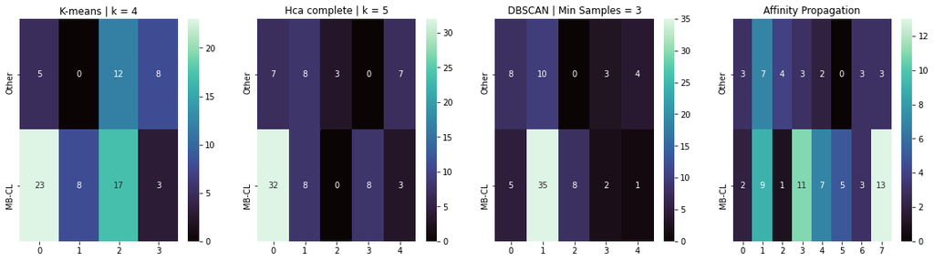

```python
fig, axs = plt.subplots(ncols=4,figsize=(20,5))
axs[0].set_title('K-means | k = 4')
axs[1].set_title('Hca complete | k = 5')
axs[2].set_title('DBSCAN | Min Samples = 3')
axs[3].set_title('Affinity Propagation')
sns.heatmap(contingency_matrix(X_variance['class'], X_variance['kmeans_4']), annot=True, fmt="d",  cmap="mako", yticklabels = ['Other','MB-CL'], ax=axs[0])
sns.heatmap(contingency_matrix(X_variance['class'], X_variance['hca_complete_5']), annot=True, fmt="d",  cmap="mako", yticklabels = ['Other','MB-CL'], ax=axs[1])
sns.heatmap(contingency_matrix(X_variance['class'], X_variance['ap_']), annot=True, fmt="d",  cmap="mako", yticklabels = ['Other','MB-CL'],ax=axs[3])
sns.heatmap(contingency_matrix(X_variance['class'], X_variance['DBSCAN_3']), annot=True, fmt="d",  cmap="mako", yticklabels = ['Other','MB-CL'],ax=axs[2])
plt.show()
```

Olhando para as matrizes acima conseguimos comparar os resultados dos dois melhores modelos K-means, HCA e DBSCAN com o Affinity Propagation.

Apesar de o X_PCA ter dado os melhores resultados para o Affinity Propagation decidimos comparar os mesmos datasets para manter consistencia na discussao, ou seja, estamos a usar o dataset **X_variance** que deu os melhores resultados para o K-means, HCA e DBSCAN.

Através das matrizes reparamos que o Affinity Propagation é o pior no geral visto que apresenta uma maior quantidade de clusters heterogenias. Sendo as piores as **clusters representadas por 0, 1 e 6**

O Affinity Propagation apesar de ter mais clusters estes acabam por nao serem uteis visto que nao sao puros.

```python
scores_s = { 'Silhouette': [get_silhuette_score(X_variance, X_variance_cols, 'kmeans_4'), get_silhuette_score(X_variance, X_variance_cols, 'hca_complete_5'), get_silhuette_score(X_variance, X_variance_cols, 'DBSCAN_3'), get_silhuette_score(X_variance, X_variance_cols, 'ap_')],
             'V-Measure': [get_vmeasure(X_variance,'kmeans_4'), get_vmeasure(X_variance,'hca_complete_5'), get_vmeasure(X_variance,'DBSCAN_3'), get_vmeasure(X_variance,'ap_')],
             'Models': ['Kmeans_k4','Hca_complete_k5', 'DBSCAN_3','Affinity Propagation']}

scores_s_df = pd.DataFrame(scores_s)
scores_s_df
```

|  | Silhouette | V-Measure | Models |
| --- | --- | --- | --- |
| 0 | 0.236240 | 0.124052 | Kmeans_k4 |
| 1 | 0.235139 | 0.171170 | Hca_complete_k5 |
| 2 | 0.145202 | 0.139744 | DBSCAN_3 |
| 3 | 0.111480 | 0.075018 | Affinity Propagation |

Olhando agora para os resultados das métricas usadas para cada algoritmo:

**Silhouette Score:**

- K-means | k = 4 ---> 0.236
- HCA Complete | k = 5 ---> 0.235
- DBSCAN ---> 0.145
- Affinity Propagation ---> 0.111

**V-Measure:**

- K-means | k = 4 ---> 0.124
- HCA Complete | k = 5 ---> 0.171
- DBSCAN ---> 0.139
- Affinity Propagation ---> 0.075

Novamente notámos que de todos os algoritmos o com pior qualidade de *clusters* formadas é o Affinity Propagation, uma das possiveis explicacoes é da forma como o algoritmo funciona perante os nossos dados onde as *samples* fazem clustering por afinidade através de 'mensagens' entre pares de samples até convergirem.

Como os nossos dados nao estao propriamente bem separados este algoritmo de clustering falha em encontrar as melhores clusters possiveis.

## Spectral Clustering

É um algoritmo de clustering baseado em grafos, no sentido em que os dados são primeiro traduzidos em grafos e as clusters são encontradas através dos grafos gerados. De seguida, estes são novamente traduzidos para dados.

Uma das vantagens deste algoritmo é que em contraste com o K-Means as clusters não assumem uma distribuicao/forma, ou seja, este algoritmo é versátil para uma grande variedade de distribuicao de dados, daí o acharmos interessante para a nossa análise.

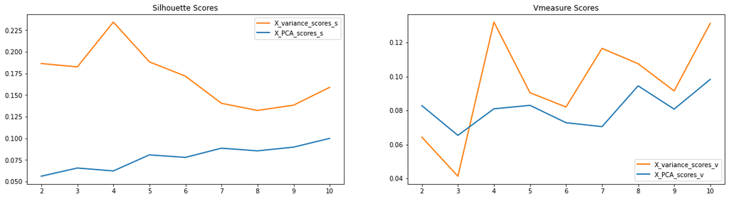

```python
plot_models('spectral', 10, dfs, cols)
```

Observando os graficos acima, que compara scores com o numero de clusters geradas, retiramos a conclusão que este algoritmo de clustering lida bem quando existe um elevado numero de features, visto que no caso do dataset da X_variance que é constituido por 317 features estamos a obter Silhoette Scores e V-Measure relativamente altos.

Apos analise dos graficos acima o Spectral Clustering maximizou os scores Silhouette e Vmeasure para 4 clusters.

```python
sc_clusters = {'clusters': [], 'size': [], 'silhouette': [], 'vmeasure': []}
for idx, df in enumerate(dfs):
    clusters, scores = perform_SC(df, cols[idx], 4)
    sc_clusters['clusters'].append(clusters)
    sc_clusters['size'].append(len(clusters))
    sc_clusters['silhouette'].append(scores['silhouette'])
    sc_clusters['vmeasure'].append(scores['vmeasure'])
```

```python
sc_df = pd.DataFrame.from_dict(sc_clusters).T
sc_df.columns = ['X_variance', 'X_PCA']
sc_df
```

|  | X_variance | X_PCA |
| --- | --- | --- |
| clusters | {1: {'MB-CL': 22, 'Other': 4}, 3: {'MB-CL': 8,... | {0: {'MB-CL': 30, 'Other': 22}, 3: {'MB-CL': 7... |
| size | 4 | 4 |
| silhouette | 0.234382 | 0.0623786 |
| vmeasure | 0.132079 | 0.0810215 |

Como se pode observar na tabela o X_variance é o dataset com scores melhores.

Posto isto, vamos de seguida analisar os melhores X_variance de todos os algoritmos de clustering (K-Means, HCA e DBSCAN).

### Spectral Clustering vs K-means, HCA and DBSCAN

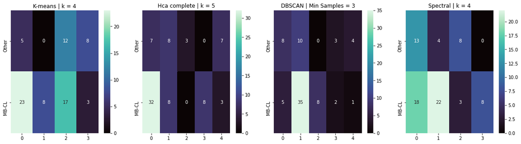

```python
fig, axs = plt.subplots(ncols=4,figsize=(20,5))
axs[0].set_title('K-means | k = 4')
axs[1].set_title('Hca complete | k = 5')
axs[2].set_title('DBSCAN | Min Samples = 3')
axs[3].set_title('Spectral | k = 4')
sns.heatmap(contingency_matrix(X_variance['class'], X_variance['kmeans_4']), annot=True, fmt="d",  cmap="mako", yticklabels = ['Other','MB-CL'], ax=axs[0])
sns.heatmap(contingency_matrix(X_variance['class'], X_variance['hca_complete_5']), annot=True, fmt="d",  cmap="mako", yticklabels = ['Other','MB-CL'], ax=axs[1])
sns.heatmap(contingency_matrix(X_variance['class'], X_variance['sc_4']), annot=True, fmt="d",  cmap="mako", yticklabels = ['Other','MB-CL'],ax=axs[3])
sns.heatmap(contingency_matrix(X_variance['class'], X_variance['DBSCAN_3']), annot=True, fmt="d",  cmap="mako", yticklabels = ['Other','MB-CL'],ax=axs[2])
plt.show()
```

Olhando para as matrizes acima conseguimos comparar os resultados dos melhores modelos K-means, HCA e DBSCAN com o Spectral.

Através das matrizes representadas acima reparamos que o Spectral dá resultados muito semelhantes ao K-means. Ambos apresentam uma cluster pura e no geral clusters muito similares alterando apenas algumas samples.

```python
scores_s = { 'Silhouette': [get_silhuette_score(X_variance, X_variance_cols, 'kmeans_4'), get_silhuette_score(X_variance, X_variance_cols, 'hca_complete_5'), get_silhuette_score(X_variance, X_variance_cols, 'DBSCAN_3'), get_silhuette_score(X_variance, X_variance_cols, 'sc_4')],
             'V-Measure': [get_vmeasure(X_variance,'kmeans_4'), get_vmeasure(X_variance,'hca_complete_5'), get_vmeasure(X_variance,'DBSCAN_3'), get_vmeasure(X_variance,'sc_4')],
             'Models': ['Kmeans_k4','Hca_complete_k5', 'DBSCAN_3', 'Spectral_k4']}

scores_s_df = pd.DataFrame(scores_s)
scores_s_df
```

|  | Silhouette | V-Measure | Models |
| --- | --- | --- | --- |
| 0 | 0.236240 | 0.124052 | Kmeans_k4 |
| 1 | 0.235139 | 0.171170 | Hca_complete_k5 |
| 2 | 0.145202 | 0.139744 | DBSCAN_3 |
| 3 | 0.234382 | 0.132079 | Spectral_k4 |

**Silhouette Score:**

- K-means | k = 4 ---> 0.236
- HCA Complete | k = 5 ---> 0.235
- DBSCAN ---> 0.145
- Spectral ---> 0.234

**V-Measure:**

- K-means | k = 4 ---> 0.124
- HCA Complete | k = 5 ---> 0.171
- DBSCAN ---> 0.139
- Spectral ---> 0.132

Ao observar a tabela representada acima vemos que o Spectral com 4 clusters consegue obter resultados ligeiramente melhores que o K-means com 4 clusters, em relacao à constituicao destas clusters.

## 8. Conclusions

A primeira grande conclusão que tiramos deste trabalho é de que o processo de escolha dos diversos parametros para redução da dimensionalidade dos nossos dados é iterativo. No nosso caso, começamos por escolher valores arbitrarios para os nossos *thresholds* de variancia. Na segunda iteração, tentamos olhar para os silhouete scores para fazer esta escolha de uma forma mais informada. Verificamos que para obter resultados razoaveis temos que definir os thresholds de forma a manter pelo menos cerca de metade da variancia dos dados explicada. Por fim, nesta ultima iteração fizemos a escolha com base numa analise conjunta do *silhouette score* e *v-measure* visto que tinhamos acesso as *labels* de *ground truth* das instancias dos nossos dados, e com isto conseguimos obter os melhores resultados de todas as iterações, e conseguimos visualizar e justificar o porquê da escolha dos valores de *threshold* nos plots do ponto 2.

A segunda grande conclusão a que chegamos foi que, por muito que variemos os nossos thresholds, metodos de clustering, distancias, metodos de linkage, os nossos resultados vão sempre acabar por atingir um *plateau* definido pela qualidade dos nossos dados. O mesmo poder ser dito sobre os metodos de redução de dimensionalidade dos nossos dados. Se os dados não apresentam boas carateristicas (p.e bons valores de correlação) não podemos esperar boas reduções feitas pelo metodo **PCA**.

Relativamente ao **DBSCAN** e ao **OPTICS**, são ambos algoritmos bastante interessantes na forma em que conseguem formar os clusters, no entanto são preferencialmente utilizados se tivermos uma quantidade de dados maior, ao contrário do nosso caso que temos apenas 76 amostras, e também não se pretende dados com uma dimensionalidade muito grande.

Ainda assim conseguimos obter clusters interessantes, apesar de na nossa opinião o **HCA** ter sido ligeiramente melhor, comportaram-se de forma bastante positiva mesmo para a pequena quantidade de dados fornecida e para o valor de features que os nossos dados tinham.

Por fim, tentámos retirar alguns insights a cerca dos tipos de meduloblastoma porem achamos esta tarefa bastante dificil. Com base na pesquisa feita, e na analise dos nossos dados achamos que esta dificuldade passa pelo seguinte:

- Existem demasiadas features para que os algoritmos de clustering consigam ter um bom desempenho;
- Não existem features capazes de diferenciar bem os varios tipos de doenças;
- A redução da dimensão oferece algumas melhorias, mas mesmo assim, os dados não permitem uma boa separação das classes.

Portanto, se com base nas features numericas não é possivel fazer uma boa separação das classes de meduloblastoma, significa que, apesar de algumas diferenças entre si estarem presentes nos valores numericos para as enumeras features que nos foram fornecidas, para fazer uma boa separação, deverá ser necessario ter em conta mais formas de diferenciação.